```python
import pandas as pd
import numpy as np
import seaborn as sns
import datetime
color = sns.color_palette()

%matplotlib inline
```

```python
#Import Files
df_parking_payment = pd.read_csv("/Users/niranjan/Desktop/Parking_Meter/treas_parking_payments_2017_datasd.csv")
df_meter_location  = pd.read_csv("/Users/niranjan/Desktop/Parking_Meter/treas_parking_meters_loc_datasd.csv")
```

```python
df_meter_location=df_meter_location.rename(columns = {'pole':'pole_id'})
df_meter_location.head(5)
```

|  | zone | area | sub_area | pole_id | config_id | config_name | longitude | latitude |
| --- | --- | --- | --- | --- | --- | --- | --- | --- |
| 0 | City | Barrio Logan | 1000 CESAR CHAVEZ WAY | CC-1003 | 9000 | 2 Hour Max $1.25 HR 8am-6pm Mon-Sat | -117.145178 | 32.700353 |
| 1 | City | Barrio Logan | 1000 CESAR CHAVEZ WAY | CC-1005 | 9000 | 2 Hour Max $1.25 HR 8am-6pm Mon-Sat | -117.145178 | 32.700352 |
| 2 | City | Barrio Logan | 1000 CESAR CHAVEZ WAY | CC-1011 | 9000 | 2 Hour Max $1.25 HR 8am-6pm Mon-Sat | -117.145349 | 32.700155 |
| 3 | City | Barrio Logan | 1000 CESAR CHAVEZ WAY | CC-1013 | 9000 | 2 Hour Max $1.25 HR 8am-6pm Mon-Sat | -117.145405 | 32.700107 |
| 4 | City | Barrio Logan | 1000 CESAR CHAVEZ WAY | CC-1015 | 9000 | 2 Hour Max $1.25 HR 8am-6pm Mon-Sat | -117.145539 | 32.699987 |

```python
df_parking_payment.head(5)
```

|  | uuid | meter_type | pole_id | trans_amt | pay_method | trans_start | meter_expire |
| --- | --- | --- | --- | --- | --- | --- | --- |
| 0 | SSSL21617010100151855 | SS | SL-216 | 55 | CASH | 2017-01-01 00:15:18 | 2017-01-01 00:15:18 |
| 1 | SS5402170101010349100 | SS | 5-402 | 100 | CASH | 2017-01-01 01:03:49 | 2017-01-01 01:03:49 |
| 2 | SSG503170101012353100 | SS | G-503 | 100 | CASH | 2017-01-01 01:23:53 | 2017-01-01 01:23:53 |
| 3 | SSG50317010101270125 | SS | G-503 | 25 | CASH | 2017-01-01 01:27:01 | 2017-01-01 01:27:01 |
| 4 | SSG50317010101271925 | SS | G-503 | 25 | CASH | 2017-01-01 01:27:19 | 2017-01-01 01:27:19 |

```python
#Changing the datatype of start and expire columns
df_parking_payment.trans_start  = pd.to_datetime(df_parking_payment.trans_start.astype(str))
df_parking_payment.meter_expire = pd.to_datetime(df_parking_payment.meter_expire.astype(str))
```

```python
#Extract year,month and date from transaction starting date and meter expire date
#Starting Date
df_parking_payment['start_year'] = df_parking_payment['trans_start'].dt.year
df_parking_payment['start_month'] = df_parking_payment['trans_start'].dt.month
df_parking_payment['start_day'] = df_parking_payment['trans_start'].dt.day
#Starting hour and minute
df_parking_payment['start_hour'] = df_parking_payment.trans_start.apply(lambda x: x.hour)
df_parking_payment['start_minute'] = df_parking_payment.trans_start.apply(lambda x: x.minute)


#Meter Expire Date
df_parking_payment['expire_year'] = df_parking_payment['meter_expire'].dt.year
df_parking_payment['expire_month'] = df_parking_payment['meter_expire'].dt.month
df_parking_payment['expire_day'] = df_parking_payment['meter_expire'].dt.day
#Expire hour and minute
df_parking_payment['expire_hour'] = df_parking_payment.meter_expire.apply(lambda x:x.hour)
df_parking_payment['expire_minute'] = df_parking_payment.meter_expire.apply(lambda x:x.minute)
```

```python
# Filter data between 8AM to 6PM for the month of March
df_parking_payment_filter = df_parking_payment[df_parking_payment['start_hour'].between(8, 18, inclusive=True)]
df_parking_payment_filter = df_parking_payment_filter[df_parking_payment_filter['start_month'] == 3]
```

```python
#Create time intervals - Start time
def interval_creation(row):
    if row['start_minute'] >=0 and row['start_minute'] < 5:
        val = str(row['start_hour'])+":"+"00"
    elif row['start_minute'] >=5 and row['start_minute'] < 10:
        val = str(row['start_hour'])+":"+"05"
    elif row['start_minute'] >=10 and row['start_minute'] < 15:
        val = str(row['start_hour'])+":"+"10"
    elif row['start_minute'] >=15 and row['start_minute'] < 20:
        val = str(row['start_hour'])+":"+"15"
    elif row['start_minute'] >=20 and row['start_minute'] < 25:
        val = str(row['start_hour'])+":"+"20"
    elif row['start_minute'] >=25 and row['start_minute'] < 30:
        val = str(row['start_hour'])+":"+"25"
    elif row['start_minute'] >=30 and row['start_minute'] < 35:
        val = str(row['start_hour'])+":"+"30"
    elif row['start_minute'] >=35 and row['start_minute'] < 40:
        val = str(row['start_hour'])+":"+"35"
    elif row['start_minute'] >=40 and row['start_minute'] < 45:
        val = str(row['start_hour'])+":"+"40"
    elif row['start_minute'] >=45 and row['start_minute'] < 50:
        val = str(row['start_hour'])+":"+"45"
    elif row['start_minute'] >=50 and row['start_minute'] < 55:
        val = str(row['start_hour'])+":"+"50"
    else:
        val = str(row['start_hour'])+":"+"55"

    return val

df_parking_payment_filter['starting_interval'] = df_parking_payment_filter.apply(interval_creation,axis = 1)
```

```python
#Create time intervals - Expire time
def interval_creation_expire(row):
    if row['expire_minute'] >=0 and row['expire_minute'] < 5:
        val = str(row['expire_hour'])+":"+"00"
    elif row['expire_minute'] >=5 and row['expire_minute'] < 10:
        val = str(row['expire_hour'])+":"+"05"
    elif row['expire_minute'] >=10 and row['expire_minute'] < 15:
        val = str(row['expire_hour'])+":"+"10"
    elif row['expire_minute'] >=15 and row['expire_minute'] < 20:
        val = str(row['expire_hour'])+":"+"15"
    elif row['expire_minute'] >=20 and row['expire_minute'] < 25:
        val = str(row['expire_hour'])+":"+"20"
    elif row['expire_minute'] >=25 and row['expire_minute'] < 30:
        val = str(row['expire_hour'])+":"+"25"
    elif row['expire_minute'] >=30 and row['expire_minute'] < 35:
        val = str(row['expire_hour'])+":"+"30"
    elif row['expire_minute'] >=35 and row['expire_minute'] < 40:
        val = str(row['expire_hour'])+":"+"35"
    elif row['expire_minute'] >=40 and row['expire_minute'] < 45:
        val = str(row['expire_hour'])+":"+"40"
    elif row['expire_minute'] >=45 and row['expire_minute'] < 50:
        val = str(row['expire_hour'])+":"+"45"
    elif row['expire_minute'] >=50 and row['expire_minute'] < 55:
        val = str(row['expire_hour'])+":"+"50"
    else:
        val = str(row['expire_hour'])+":"+"55"

    return val

df_parking_payment_filter['expire_interval'] = df_parking_payment_filter.apply(interval_creation_expire,axis = 1)
```

```python
#Merge payment and pole location data
df_parking_payment_location = pd.merge(df_parking_payment_filter,df_meter_location, on = 'pole_id',how = 'left')
df_parking_payment_location.head(5)
```

|  | uuid | meter_type | pole_id | trans_amt | pay_method | trans_start | meter_expire | start_year | start_month | start_day | ... | expire_minute | starting_interval | expire_interval | zone | area | sub_area | config_id | config_name | longitude | latitude |
| --- | --- | --- | --- | --- | --- | --- | --- | --- | --- | --- | --- | --- | --- | --- | --- | --- | --- | --- | --- | --- | --- |
| 0 | SSIV32217030108000090 | SS | IV-322 | 90 | CASH | 2017-03-01 08:00:00 | 2017-03-01 08:43:13 | 2017 | 3 | 1 | ... | 43 | 8:00 | 8:40 | Uptown | Bankers Hill | 300 IVY ST | 9000.0 | 2 Hour Max $1.25 HR 8am-6pm Mon-Sat | -117.161556 | 32.728406 |
| 1 | SS1353817030108000015 | SS | 13-538 | 15 | CASH | 2017-03-01 08:00:00 | 2017-03-01 08:19:13 | 2017 | 3 | 1 | ... | 19 | 8:00 | 8:15 | Downtown | East Village | 500 THIRTEENTH ST | 14760.0 | 2 Hour Max $1.25 HR 8am-6pm Mon-Sat (Mobi... | -117.152933 | 32.711330 |
| 2 | SS43537170301080001250 | SS | 4-3537 | 250 | CREDIT CARD | 2017-03-01 08:00:01 | 2017-03-01 10:00:01 | 2017 | 3 | 1 | ... | 0 | 8:00 | 10:00 | Uptown | Hillcrest | 3500 FOURTH AVE | 13442.0 | 2 Hour Max $1.25 HR 10am-8pm Mon-Sat (Mobile Pay) | -117.161481 | 32.742997 |
| 3 | SSWBE31317030108000110 | SS | WBE-313 | 10 | CASH | 2017-03-01 08:00:01 | 2017-03-01 08:04:49 | 2017 | 3 | 1 | ... | 4 | 8:00 | 8:00 | Downtown | Little Italy | 300 WEST BEECH ST | 9290.0 | 15 Min Max $1.25 HR 8am-6pm Mon-Sat | -117.161584 | 32.720860 |
| 4 | SSP172017030108000225 | SS | P-1720 | 25 | CASH | 2017-03-01 08:00:02 | 2017-03-01 08:12:02 | 2017 | 3 | 1 | ... | 12 | 8:00 | 8:10 | Downtown | Little Italy | 1700 PACIFIC HIGHWAY | 12494.0 | 2 Hour Max $1.25 HR 8am-6pm Mon-Sat (Mobile Pay) | -117.171234 | 32.723730 |

5 rows × 26 columns

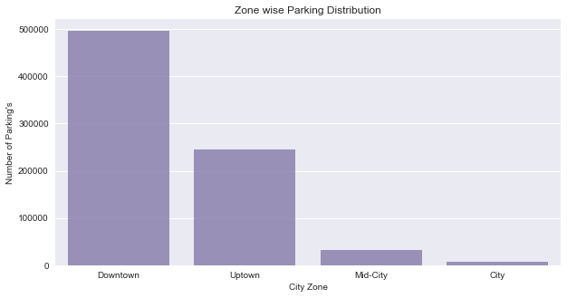

```python
#Zone wise Distribution
cnt_zone_values = df_parking_payment_location.zone.value_counts()
plt.figure(figsize= (10,5))
sns.barplot(cnt_zone_values.index, cnt_zone_values.values,alpha = 0.8,color = color[3])
plt.xlabel("City Zone",fontsize = 10)
plt.ylabel("Number of Parking's",fontsize = 10)
plt.title("Zone wise Parking Distribution")
plt.show()
```

```python
import warnings
warnings.filterwarnings('ignore')
```

As city only charge for parking between 8AM-6PM, we will change the expire hour to 18 whereever expire hour is greater than 18(6PM) and will update the exxpire minutes to 0 and interval to 18:00 (6PM) accordingly

```python
df_parking_payment_location.ix[df_parking_payment_location.expire_hour > 18,'expire_hour'] = 18
df_parking_payment_location.ix[df_parking_payment_location.expire_hour == 18,'expire_minute'] = 0
df_parking_payment_location.ix[df_parking_payment_location.expire_hour == 18,'expire_interval'] = '18:00'
```

```python
df_parking_payment_location_1 = df_parking_payment_location[['pole_id','sub_area','start_year','start_month','start_day','trans_start','meter_expire','starting_interval','expire_interval']]
df_parking_payment_location_1.head(5)
```

|  | pole_id | sub_area | start_year | start_month | start_day | trans_start | meter_expire | starting_interval | expire_interval |
| --- | --- | --- | --- | --- | --- | --- | --- | --- | --- |
| 0 | IV-322 | 300 IVY ST | 2017 | 3 | 1 | 2017-03-01 08:00:00 | 2017-03-01 08:43:13 | 8:00 | 8:40 |
| 1 | 13-538 | 500 THIRTEENTH ST | 2017 | 3 | 1 | 2017-03-01 08:00:00 | 2017-03-01 08:19:13 | 8:00 | 8:15 |
| 2 | 4-3537 | 3500 FOURTH AVE | 2017 | 3 | 1 | 2017-03-01 08:00:01 | 2017-03-01 10:00:01 | 8:00 | 10:00 |
| 3 | WBE-313 | 300 WEST BEECH ST | 2017 | 3 | 1 | 2017-03-01 08:00:01 | 2017-03-01 08:04:49 | 8:00 | 8:00 |
| 4 | P-1720 | 1700 PACIFIC HIGHWAY | 2017 | 3 | 1 | 2017-03-01 08:00:02 | 2017-03-01 08:12:02 | 8:00 | 8:10 |

```python
#Starting Interval Count
df_count_starting_interval = df_parking_payment_location_1.groupby(['pole_id','sub_area','start_year','start_month','start_day','starting_interval']).count().reset_index()
df_count_starting_interval =df_count_starting_interval.rename(columns = {'trans_start':'starting_interval_count'})
df_count_starting_interval.drop(['meter_expire','expire_interval'],axis = 1, inplace= True)
df_count_starting_interval.head(5)
```

|  | pole_id | sub_area | start_year | start_month | start_day | starting_interval | starting_interval_count |
| --- | --- | --- | --- | --- | --- | --- | --- |
| 0 | 1-1004 | 1000 FIRST AVE | 2017 | 3 | 1 | 10:05 | 2 |
| 1 | 1-1004 | 1000 FIRST AVE | 2017 | 3 | 1 | 11:00 | 1 |
| 2 | 1-1004 | 1000 FIRST AVE | 2017 | 3 | 1 | 11:35 | 1 |
| 3 | 1-1004 | 1000 FIRST AVE | 2017 | 3 | 1 | 13:05 | 1 |
| 4 | 1-1004 | 1000 FIRST AVE | 2017 | 3 | 1 | 14:40 | 1 |

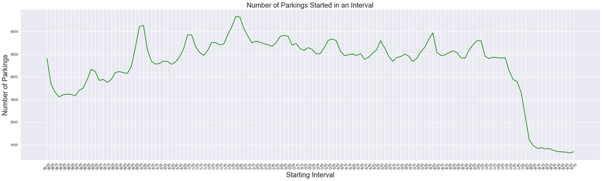

```python
#Distribution of Starting Interval
cnt_starting_interval = df_count_starting_interval.starting_interval.value_counts().reset_index()
cnt_starting_interval = cnt_starting_interval.rename(columns = {'index':'time_interval'})
cnt_starting_interval = cnt_starting_interval.rename(columns = {'starting_interval':'starting_interval_count'})

def append_zero(row):
    val = row['time_interval']
    if val[0] == '8' or val[0] == '9':
        val_1 = "0" +val
    else:
        val_1 = val

    return val_1


cnt_starting_interval['time_interval'] = cnt_starting_interval.apply(append_zero,axis = 1)
cnt_starting_interval = cnt_starting_interval.sort_values(['time_interval'])
import pylab
names = pd.Series(cnt_starting_interval.time_interval)
counts = pd.Series(cnt_starting_interval.starting_interval_count)
pylab.figure(figsize = (30,8))
X = range(len(cnt_starting_interval.time_interval))
pylab.xticks(X, names,rotation = "45")
pylab.title("Number of Parkings Started in an Interval",fontsize = 20)
pylab.xlabel("Starting Interval",fontsize = 20)
pylab.ylabel("Number of Parkings",fontsize = 20)
pylab.plot(X,counts,"g")
pylab.show()
```

```python
#Expire Interval Count
df_count_expire_interval = df_parking_payment_location_1.groupby(['pole_id','sub_area','start_year','start_month','start_day','expire_interval']).count().reset_index()
df_count_expire_interval = df_count_expire_interval.rename(columns = {'trans_start':'Expire_interval_count'})
df_count_expire_interval.drop(['meter_expire','starting_interval'],axis = 1, inplace= True)
df_count_expire_interval.head(5)
```

|  | pole_id | sub_area | start_year | start_month | start_day | expire_interval | Expire_interval_count |
| --- | --- | --- | --- | --- | --- | --- | --- |
| 0 | 1-1004 | 1000 FIRST AVE | 2017 | 3 | 1 | 10:30 | 1 |
| 1 | 1-1004 | 1000 FIRST AVE | 2017 | 3 | 1 | 10:40 | 1 |
| 2 | 1-1004 | 1000 FIRST AVE | 2017 | 3 | 1 | 13:00 | 1 |
| 3 | 1-1004 | 1000 FIRST AVE | 2017 | 3 | 1 | 13:35 | 1 |
| 4 | 1-1004 | 1000 FIRST AVE | 2017 | 3 | 1 | 14:45 | 1 |

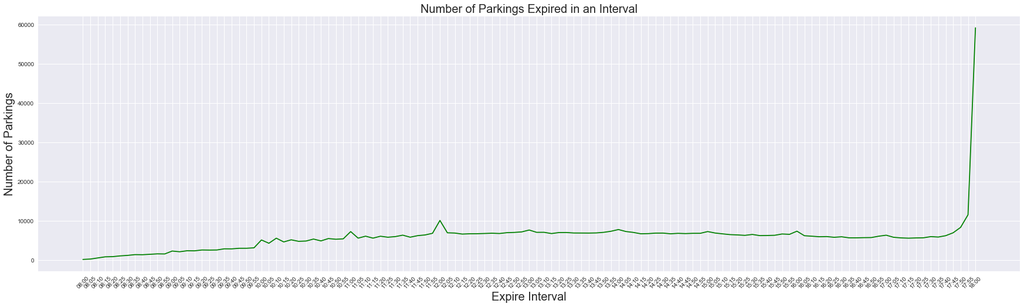

```python
#Distribution of Expire Interval
cnt_expire_interval = df_count_expire_interval.expire_interval.value_counts().reset_index()
cnt_expire_interval = cnt_expire_interval.rename(columns = {'index':'time_interval'})
cnt_expire_interval = cnt_expire_interval.rename(columns = {'expire_interval':'expire_interval_count'})

def append_zero(row):
    val = row['time_interval']
    if val[0] == '8' or val[0] == '9':
        val_1 = "0" +val
    else:
        val_1 = val

    return val_1


cnt_expire_interval['time_interval'] = cnt_expire_interval.apply(append_zero,axis = 1)
cnt_expire_interval = cnt_expire_interval.sort_values(['time_interval'])

import pylab
names = pd.Series(cnt_expire_interval.time_interval)
counts = pd.Series(cnt_expire_interval.expire_interval_count)
pylab.figure(figsize = (30,8))
X = range(len(cnt_expire_interval.time_interval))
pylab.xticks(X, names,rotation = "45")
pylab.title("Number of Parkings Expired in an Interval",fontsize = 20)
pylab.xlabel("Expire Interval",fontsize = 20)
pylab.ylabel("Number of Parkings",fontsize = 20)
pylab.plot(X,counts,"g")
pylab.show()
```

## Number of parkings expired in last interval is very high as during the data preparation part, if the expire interval is greater than 6PM, we have converted that time into 6.00 PM, as the meter parking is charged till 6PM

```python
#Finding the time for which the pole was occupied
import datetime
def add_time(row):
    x = abs((row['trans_start'].minute % 5) - 5)
    val = row['trans_start'] + datetime.timedelta(minutes = x)
    if row['meter_expire'] > val:
        val1 = val - row['trans_start']
    else:
        val1 = row['meter_expire'] - row['trans_start']
    return val1


df_parking_payment_location_1['Acutal_Parking_Occupied_Time'] = df_parking_payment_location_1.apply(add_time,axis = 1)
df_parking_payment_location_1.head(5)
```

|  | pole_id | sub_area | start_year | start_month | start_day | trans_start | meter_expire | starting_interval | expire_interval | Acutal_Parking_Occupied_Time |
| --- | --- | --- | --- | --- | --- | --- | --- | --- | --- | --- |
| 0 | IV-322 | 300 IVY ST | 2017 | 3 | 1 | 2017-03-01 08:00:00 | 2017-03-01 08:43:13 | 8:00 | 8:40 | 00:05:00 |
| 1 | 13-538 | 500 THIRTEENTH ST | 2017 | 3 | 1 | 2017-03-01 08:00:00 | 2017-03-01 08:19:13 | 8:00 | 8:15 | 00:05:00 |
| 2 | 4-3537 | 3500 FOURTH AVE | 2017 | 3 | 1 | 2017-03-01 08:00:01 | 2017-03-01 10:00:01 | 8:00 | 10:00 | 00:05:00 |
| 3 | WBE-313 | 300 WEST BEECH ST | 2017 | 3 | 1 | 2017-03-01 08:00:01 | 2017-03-01 08:04:49 | 8:00 | 8:00 | 00:04:48 |
| 4 | P-1720 | 1700 PACIFIC HIGHWAY | 2017 | 3 | 1 | 2017-03-01 08:00:02 | 2017-03-01 08:12:02 | 8:00 | 8:10 | 00:05:00 |

```python
occupied_interval = df_parking_payment_location_1.groupby(['pole_id','sub_area','start_year','start_month','start_day','starting_interval'])[['Acutal_Parking_Occupied_Time']].sum().reset_index()
occupied_interval.head(5)
```

|  | pole_id | sub_area | start_year | start_month | start_day | starting_interval | Acutal_Parking_Occupied_Time |
| --- | --- | --- | --- | --- | --- | --- | --- |
| 0 | 1-1004 | 1000 FIRST AVE | 2017 | 3 | 1 | 10:05 | 00:06:00 |
| 1 | 1-1004 | 1000 FIRST AVE | 2017 | 3 | 1 | 11:00 | 00:03:00 |
| 2 | 1-1004 | 1000 FIRST AVE | 2017 | 3 | 1 | 11:35 | 00:03:00 |
| 3 | 1-1004 | 1000 FIRST AVE | 2017 | 3 | 1 | 13:05 | 00:01:00 |
| 4 | 1-1004 | 1000 FIRST AVE | 2017 | 3 | 1 | 14:40 | 00:04:00 |

```python
#Merge df_count_starting_interval and occupied_interval
from datetime import datetime as dt
df_starting_interval_occupied = pd.merge(df_count_starting_interval,occupied_interval,
                                left_on = ['pole_id','sub_area','start_year','start_month','start_day','starting_interval'],
                                right_on = ['pole_id','sub_area','start_year','start_month','start_day','starting_interval'],
                                how = "inner")

def per_time_occupied(row):
    total_interval = row['starting_interval_count'] *5*60
    x = row['Acutal_Parking_Occupied_Time']
    val = x/total_interval
    return val


df_starting_interval_occupied['Paid_Occupied_Percentage'] = df_starting_interval_occupied.apply(per_time_occupied,axis = 1)

df_starting_interval_occupied.head(5)
```

|  | pole_id | sub_area | start_year | start_month | start_day | starting_interval | starting_interval_count | Acutal_Parking_Occupied_Time | Paid_Occupied_Percentage |
| --- | --- | --- | --- | --- | --- | --- | --- | --- | --- |
| 0 | 1-1004 | 1000 FIRST AVE | 2017 | 3 | 1 | 10:05 | 2 | 00:06:00 | 00:00:00.600000 |
| 1 | 1-1004 | 1000 FIRST AVE | 2017 | 3 | 1 | 11:00 | 1 | 00:03:00 | 00:00:00.600000 |
| 2 | 1-1004 | 1000 FIRST AVE | 2017 | 3 | 1 | 11:35 | 1 | 00:03:00 | 00:00:00.600000 |
| 3 | 1-1004 | 1000 FIRST AVE | 2017 | 3 | 1 | 13:05 | 1 | 00:01:00 | 00:00:00.200000 |
| 4 | 1-1004 | 1000 FIRST AVE | 2017 | 3 | 1 | 14:40 | 1 | 00:04:00 | 00:00:00.800000 |

```python
#Convert Paid_Occupied_Percentage into string format
df_starting_interval_occupied['Paid_Occupied_Percentage'] = df_starting_interval_occupied['Paid_Occupied_Percentage'].astype(str)


def dtype_change(row):
    location = row['Paid_Occupied_Percentage'].index('.')
    val = row['Paid_Occupied_Percentage']
    x = val[location:]
    return x


df_starting_interval_occupied['Paid_Occupied_Percentage_Final'] = df_starting_interval_occupied.apply(dtype_change,axis = 1)
```

```python
#Merge df_starting_interval_occupied and df_count_expire_interval
df_starting_expire_ocupied = pd.merge(df_starting_interval_occupied[['pole_id', 'sub_area', 'start_year', 'start_month', 'start_day','starting_interval', 'starting_interval_count','Paid_Occupied_Percentage_Final']],
                                      df_count_expire_interval,
                                      left_on = ['pole_id','sub_area','start_year','start_month','start_day','starting_interval'],
                                      right_on = ['pole_id','sub_area','start_year','start_month','start_day','expire_interval'],
                                      how = "outer")

df_starting_expire_ocupied['Paid_Occupied_Percentage_Final'] = df_starting_expire_ocupied['Paid_Occupied_Percentage_Final'].astype(str).astype(float)
df_starting_expire_ocupied.fillna('-',inplace = True)
df_starting_expire_ocupied=df_starting_expire_ocupied.rename(columns = {'Paid_Occupied_Percentage_Final':'Paid_Occupied_Percentage'})

df_starting_expire_ocupied.head(5)
```

|  | pole_id | sub_area | start_year | start_month | start_day | starting_interval | starting_interval_count | Paid_Occupied_Percentage | expire_interval | Expire_interval_count |
| --- | --- | --- | --- | --- | --- | --- | --- | --- | --- | --- |
| 0 | 1-1004 | 1000 FIRST AVE | 2017 | 3 | 1 | 10:05 | 2 | 0.6 | - | - |
| 1 | 1-1004 | 1000 FIRST AVE | 2017 | 3 | 1 | 11:00 | 1 | 0.6 | - | - |
| 2 | 1-1004 | 1000 FIRST AVE | 2017 | 3 | 1 | 11:35 | 1 | 0.6 | - | - |
| 3 | 1-1004 | 1000 FIRST AVE | 2017 | 3 | 1 | 13:05 | 1 | 0.2 | - | - |
| 4 | 1-1004 | 1000 FIRST AVE | 2017 | 3 | 1 | 14:40 | 1 | 0.8 | - | - |

```python
df_starting_expire_ocupied.to_csv("/Users/niranjan/Desktop/Parking_Meter/df_starting_expire_ocupied.csv")
```

1. Expire day is not selected as the start day and expire day are same of all the transactions
2. Months and year columns are not choosen as we are doing analysis for March 2017#'trans_start', 'meter_expire'

```python
df_parking_payment_location['Time_Difference'] = df_parking_payment_location['meter_expire'] - df_parking_payment_location['trans_start']
df_parking_prediction = df_parking_payment_location[['zone', 'area','config_id', 'trans_amt', 'start_day','starting_interval','expire_interval','Time_Difference']]
df_parking_prediction.head(3)
```

|  | zone | area | config_id | trans_amt | start_day | starting_interval | expire_interval | Time_Difference |
| --- | --- | --- | --- | --- | --- | --- | --- | --- |
| 0 | Uptown | Bankers Hill | 9000.0 | 90 | 1 | 8:00 | 8:40 | 00:43:13 |
| 1 | Downtown | East Village | 14760.0 | 15 | 1 | 8:00 | 8:15 | 00:19:13 |
| 2 | Uptown | Hillcrest | 13442.0 | 250 | 1 | 8:00 | 10:00 | 02:00:00 |

```python
#Convert Time Difference from timedelta to float - For a calculation purpose
def time_format_change(row):
    duration = row['Time_Difference']
    seconds = duration.total_seconds()
    minutes = (seconds % 3600) // 60
    return minutes

df_parking_prediction['minutes'] = df_parking_prediction.apply(time_format_change,axis = 1)

df_parking_prediction = df_parking_prediction.drop('Time_Difference', 1)
df_parking_prediction = df_parking_prediction.rename(columns = {'minutes':'Time_Difference'})
df_parking_prediction.head(3)
```

|  | zone | area | config_id | trans_amt | start_day | starting_interval | expire_interval | Time_Difference |
| --- | --- | --- | --- | --- | --- | --- | --- | --- |
| 0 | Uptown | Bankers Hill | 9000.0 | 90 | 1 | 8:00 | 8:40 | 43.0 |
| 1 | Downtown | East Village | 14760.0 | 15 | 1 | 8:00 | 8:15 | 19.0 |
| 2 | Uptown | Hillcrest | 13442.0 | 250 | 1 | 8:00 | 10:00 | 0.0 |

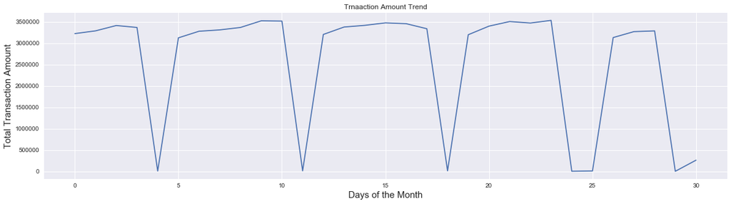

```python
#Filter transaction start time and amount and group them
df_check = df_parking_payment_location[['trans_start','trans_amt']]
df_check['trans_start'] = df_check['trans_start'].dt.date
df_check_1 = df_check.groupby('trans_start').sum().reset_index()

#Trends in transaction amount
import matplotlib.pyplot as plt
plt.figure(figsize = (20,5))
plt.plot(df_check_1.trans_amt)
plt.xlabel("Days of the Month",fontsize = 15)
plt.ylabel("Total Transaction Amount",fontsize = 15)
plt.title("Trnaaction Amount Trend")
plt.show()
```

## Observation:

It has been observed that daily revenue for the weekends dates is very low as compared to the reveune generated on the weekdays. and hence it is appropriate to seperate the data into two parts and then build the revenue model on daily basis. Keeping the threshold of 2,500,000 (as per the trends shown above) we will filter the dataset

## 1. Model Based on Trends

As mentioned above, the trends depicts that revenue is weekends are very low as compared to weekdays and hence keeping a threshold of 2,500,000, we will split the data into weekdays and weekends.

We will use SVR for weekdays revenue prediction, while we will find average trend for weekend data

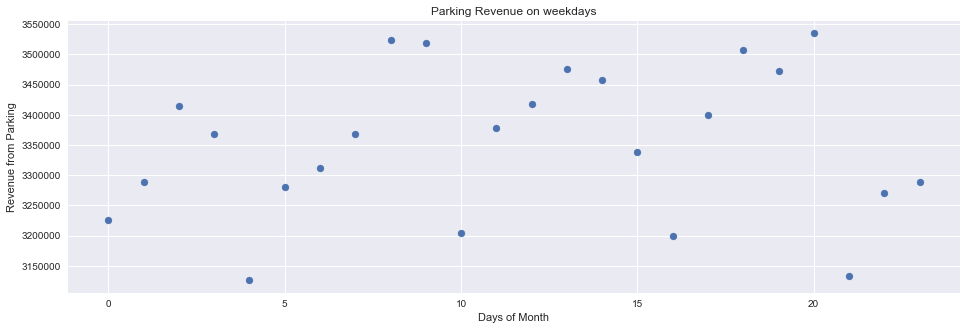

```python
df_check_weekdays = df_check_1[df_check_1.trans_amt > 2500000].trans_amt
df_check_weekdays = df_check_weekdays.reshape((len(df_check_weekdays),1))
df_check_weekdays_y = np.array(range(len(df_check_weekdays[:])))
df_check_weekdays_y = df_check_weekdays.reshape((len(df_check_weekdays),1))

import matplotlib.pyplot as plt
plt.figure(figsize= (16,5))
plt.scatter(range(len(df_check_weekdays)),df_check_weekdays)
plt.xlabel("Days of Month")
plt.ylabel("Revenue from Parking")
plt.title("Parking Revenue on weekdays")
plt.show()
```

```python
#SVR model building
from sklearn.svm import SVR
clf = SVR(C=1.0, epsilon=0.2)
clf.fit(df_check_weekdays_y[:21,:], df_check_weekdays[:21])
```

```
SVR(C=1.0, cache_size=200, coef0=0.0, degree=3, epsilon=0.2, gamma='auto',
  kernel='rbf', max_iter=-1, shrinking=True, tol=0.001, verbose=False)
```

```python
#Result of SVR
print("Actial Values:",list(df_check_weekdays[21:]))
print("Predicted Values:",clf.predict(df_check_weekdays_y[21:,:]))
print((clf.predict(df_check_weekdays_y[21:,:]) - df_check_weekdays[21:]).mean())
```

```
Actial Values: [array([3132681]), array([3271307]), array([3288627])]
Predicted Values: [ 3378723.  3378723.  3378723.]
147851.333333
```

```
Mean Revenue on weekends(without outlier): 9923.67
```

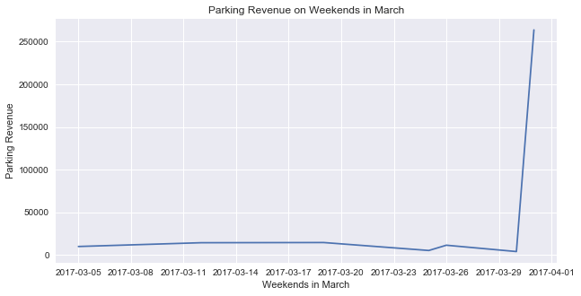

```python
df_check_weekends = df_check_1[df_check_1.trans_amt <= 2500000]
df_check_weekends.trans_start = pd.to_datetime(df_check_weekends.trans_start)
data_mean = df_check_weekends[df_check_weekends.trans_amt != 263723]
print("Mean Revenue on weekends(without outlier):",round(np.mean(data_mean.trans_amt),2))
plt.figure(figsize = (10,5))
plt.plot(df_check_weekends.trans_start,df_check_weekends.trans_amt)
plt.xlabel("Weekends in March")
plt.ylabel("Parking Revenue")
plt.title("Parking Revenue on Weekends in March")
plt.show()
```

# 2. ARIMA Model

```python
#Filter data for ARIMA Model
df_start_date_amt = df_parking_payment_location[['trans_start','trans_amt']]
df_start_date_amt.trans_start = df_start_date_amt.loc[:,'trans_start'].dt.date
df_start_date_amt.trans_start = pd.to_datetime(df_start_date_amt.trans_start)

df_start_date_amt_grouped = df_start_date_amt.groupby('trans_start').sum().reset_index()
df_start_date_amt_grouped.head(10)
```

|  | trans_start | trans_amt |
| --- | --- | --- |
| 0 | 2017-03-01 | 3225200 |
| 1 | 2017-03-02 | 3289608 |
| 2 | 2017-03-03 | 3414390 |
| 3 | 2017-03-04 | 3368592 |
| 4 | 2017-03-05 | 9930 |
| 5 | 2017-03-06 | 3126146 |
| 6 | 2017-03-07 | 3280697 |
| 7 | 2017-03-08 | 3312091 |
| 8 | 2017-03-09 | 3369005 |
| 9 | 2017-03-10 | 3524295 |

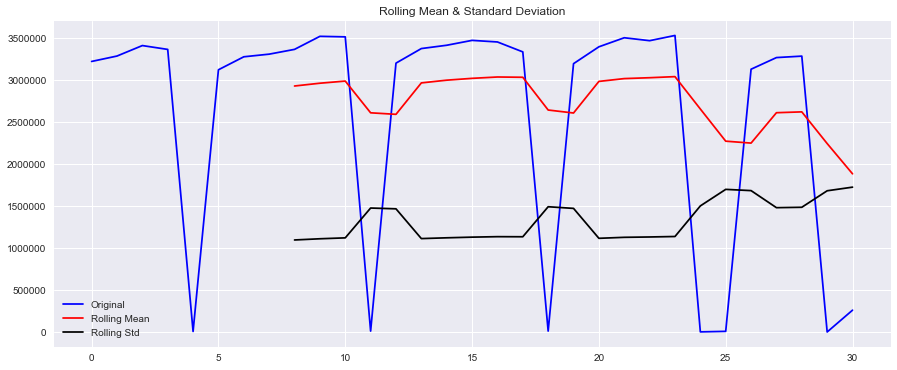

```python
rolmean = pd.rolling_mean(df_start_date_amt_grouped.trans_amt, window=9)
rolstd = pd.rolling_std(df_start_date_amt_grouped.trans_amt, window=9)

#Plot rolling statistics:
plt.figure(figsize = (15,6))
orig = plt.plot(df_start_date_amt_grouped.trans_amt, color='blue',label='Original')
mean = plt.plot(rolmean, color='red', label='Rolling Mean')
std = plt.plot(rolstd, color='black', label = 'Rolling Std')
plt.legend(loc='best')
plt.title('Rolling Mean & Standard Deviation')
plt.show(block=False)
```

```
predicted=14.095231, expected=15.000700
predicted=13.657101, expected=15.005981
predicted=13.919302, expected=8.295299
predicted=9.266047, expected=12.482655
Test MSE: 11.154
Root Mean Square Error: 3.340
```

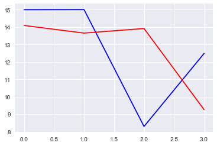

```python
trans_amt_log = np.log(df_start_date_amt_grouped.trans_amt.values)
#trans_amt_log = df_start_date_amt_grouped.trans_amt.values

from statsmodels.tsa.arima_model import ARIMA
from math import sqrt

X = trans_amt_log
size = 27 # 27 is selected for the training size as total number of records are 31 ie the number of days in March
train, test = X[0:size], X[size:len(X)]
history = [x for x in train]
predictions = list()
for t in range(len(test)):
    model = ARIMA(history, order=(5,1,0))
    model_fit = model.fit(disp=0)
    output = model_fit.forecast()
    yhat = output[0]
    predictions.append(yhat)
    obs = test[t]
    history.append(obs)
    print('predicted=%f, expected=%f' % (yhat, obs))
error = mean_squared_error(test, predictions)
print('Test MSE: %.3f' % error)
rmse = sqrt(error)
print("Root Mean Square Error: %.3f"%rmse)
# plot
plt.plot(test,color = "blue")
pyplot.plot(predictions, color='red')
pyplot.show()
```

## 3. Random Forest

```python
#Filter Data
df_parking_prediction_rf = df_parking_prediction
df_parking_prediction_rf = df_parking_prediction_rf.drop(['area','config_id'], 1)
#Create Dummy Variables
df_parking_prediction_rf = pd.get_dummies(df_parking_prediction_rf, columns = ['zone', 'starting_interval', 'expire_interval']).reset_index()
df_parking_prediction_rf = df_parking_prediction_rf.drop(['index'],1)
df_parking_prediction_rf.head(5)
```

|  | trans_amt | start_day | Time_Difference | zone_City | zone_Downtown | zone_Mid-City | zone_Uptown | starting_interval_10:00 | starting_interval_10:05 | starting_interval_10:10 | ... | expire_interval_9:10 | expire_interval_9:15 | expire_interval_9:20 | expire_interval_9:25 | expire_interval_9:30 | expire_interval_9:35 | expire_interval_9:40 | expire_interval_9:45 | expire_interval_9:50 | expire_interval_9:55 |
| --- | --- | --- | --- | --- | --- | --- | --- | --- | --- | --- | --- | --- | --- | --- | --- | --- | --- | --- | --- | --- | --- |
| 0 | 90 | 1 | 43.0 | 0 | 0 | 0 | 1 | 0 | 0 | 0 | ... | 0 | 0 | 0 | 0 | 0 | 0 | 0 | 0 | 0 | 0 |
| 1 | 15 | 1 | 19.0 | 0 | 1 | 0 | 0 | 0 | 0 | 0 | ... | 0 | 0 | 0 | 0 | 0 | 0 | 0 | 0 | 0 | 0 |
| 2 | 250 | 1 | 0.0 | 0 | 0 | 0 | 1 | 0 | 0 | 0 | ... | 0 | 0 | 0 | 0 | 0 | 0 | 0 | 0 | 0 | 0 |
| 3 | 10 | 1 | 4.0 | 0 | 1 | 0 | 0 | 0 | 0 | 0 | ... | 0 | 0 | 0 | 0 | 0 | 0 | 0 | 0 | 0 | 0 |
| 4 | 25 | 1 | 12.0 | 0 | 1 | 0 | 0 | 0 | 0 | 0 | ... | 0 | 0 | 0 | 0 | 0 | 0 | 0 | 0 | 0 | 0 |

5 rows × 260 columns

```python
#Split data into training and testing data set
from sklearn.model_selection import train_test_split

data_independent = df_parking_prediction_rf.drop(['trans_amt'],axis = 1)
data_dependent = df_parking_prediction_rf.trans_amt

X_train, X_test, y_train, y_test = train_test_split(data_dependent, data_independent, test_size=0.20, random_state=42)
```

```python
#Random Forest Model
from sklearn.ensemble import RandomForestRegressor
rf = RandomForestRegressor(n_estimators = 50)
X_train = X_train[:,None]
rf.fit(X_train, y_train)
```

```
RandomForestRegressor(bootstrap=True, criterion='mse', max_depth=None,
           max_features='auto', max_leaf_nodes=None,
           min_impurity_split=1e-07, min_samples_leaf=1,
           min_samples_split=2, min_weight_fraction_leaf=0.0,
           n_estimators=50, n_jobs=1, oob_score=False, random_state=None,
           verbose=0, warm_start=False)
```

```python
X_train = X_train[:,None]
y_predict= rf.predict(X_test)
```

```python
from sklearn.metrics import r2_score
r2 = r2_score(y_test,y_predict)
print(r2)
```

```
0.231867661781
```

As the R2, i.e, the coefficient of determination which explains the variability present in the dataset is very low approximately 23% and hence we can't use random forest regressor to predict the values, and hence we can stick to ARIMA and model designed based on the revenue trends using SVR

## Arima on Entire Dataset

```python
#Entire Dataset
df_full_data = df_parking_payment[['trans_start','trans_amt']]
df_full_data.trans_start = df_full_data.loc[:,'trans_start'].dt.date
df_full_data_grouped = df_full_data.groupby(['trans_start']).sum().reset_index()
df_full_data.head(5)
```

|  | trans_start | trans_amt |
| --- | --- | --- |
| 0 | 2017-01-01 | 55 |
| 1 | 2017-01-01 | 100 |
| 2 | 2017-01-01 | 100 |
| 3 | 2017-01-01 | 25 |
| 4 | 2017-01-01 | 25 |

```python
df_full_data_grouped = df_full_data.groupby(['trans_start']).sum().reset_index()
df_full_data_grouped.head(5)
```

|  | trans_start | trans_amt |
| --- | --- | --- |
| 0 | 2017-01-01 | 16570 |
| 1 | 2017-01-02 | 2400012 |
| 2 | 2017-01-03 | 3370936 |
| 3 | 2017-01-04 | 3380866 |
| 4 | 2017-01-05 | 3405253 |

```
Test MSE: 7.547
Root Mean Square Error: 2.747
```

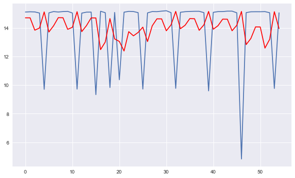

```python
trans_amt_log = np.log(df_full_data_grouped.trans_amt.values)
#trans_amt_log = df_start_date_amt_grouped.trans_amt.values

from statsmodels.tsa.arima_model import ARIMA
X = trans_amt_log
size = int(len(X) * 0.75)
train, test = X[0:size], X[size:len(X)]
history = [x for x in train]
predictions = list()
for t in range(len(test)):
    model = ARIMA(history, order=(5,1,0))
    model_fit = model.fit(disp=0)
    output = model_fit.forecast()
    yhat = output[0]
    predictions.append(yhat)
    obs = test[t]
    history.append(obs)
    #print('predicted=%f, expected=%f' % (yhat, obs))
error = mean_squared_error(test, predictions)
print('Test MSE: %.3f' % error)
rmse = sqrt(error)
print("Root Mean Square Error: %.3f"%rmse)
# plot
plt.figure(figsize = (10,6))
plt.plot(test)
plt.plot(predictions, color='red')
plt.show()
```